**Table 1. Shannon diversity index (H) and Shannon equitibility (E) for herbicide sites of action used in US corn (maize).**

| Year | Commodity | H | E |
| --- | --- | --- | --- |
| 1990 | CORN | 1.31 | 0.81 |
| 1991 | CORN | 1.49 | 0.62 |
| 1992 | CORN | 1.50 | 0.62 |
| 1993 | CORN | 1.58 | 0.72 |
| 1994 | CORN | 1.57 | 0.68 |
| 1995 | CORN | 1.60 | 0.67 |
| 1996 | CORN | 1.60 | 0.69 |
| 1997 | CORN | 1.57 | 0.68 |
| 1998 | CORN | 1.65 | 0.65 |
| 1999 | CORN | 1.74 | 0.66 |
| 2000 | CORN | 1.81 | 0.69 |
| 2001 | CORN | 1.82 | 0.69 |
| 2002 | CORN | 1.85 | 0.70 |
| 2003 | CORN | 1.89 | 0.70 |
| 2005 | CORN | 1.92 | 0.71 |
| 2010 | CORN | 1.76 | 0.62 |
| 2014 | CORN | 1.88 | 0.68 |

**Table 2. Shannon diversity index (H) and Shannon equitibility (E) for herbicide sites of action used in US soybean.**

| Year | Commodity | H | E |
| --- | --- | --- | --- |
| 1990 | SOYBEANS | 2.10 | 0.85 |
| 1991 | SOYBEANS | 1.98 | 0.80 |
| 1992 | SOYBEANS | 1.95 | 0.79 |
| 1993 | SOYBEANS | 2.05 | 0.82 |
| 1994 | SOYBEANS | 1.99 | 0.78 |
| 1995 | SOYBEANS | 2.01 | 0.78 |
| 1996 | SOYBEANS | 2.02 | 0.79 |
| 1997 | SOYBEANS | 2.04 | 0.80 |
| 1998 | SOYBEANS | 1.97 | 0.77 |
| 1999 | SOYBEANS | 1.77 | 0.69 |
| 2000 | SOYBEANS | 1.68 | 0.65 |
| 2001 | SOYBEANS | 1.51 | 0.63 |
| 2002 | SOYBEANS | 1.42 | 0.57 |
| 2004 | SOYBEANS | 1.12 | 0.47 |
| 2005 | SOYBEANS | 0.99 | 0.43 |
| 2006 | SOYBEANS | 0.94 | 0.39 |
| 2012 | SOYBEANS | 1.51 | 0.57 |

**Table 3. Shannon diversity index (H) and Shannon equitibility (E) for herbicide sites of action used in US spring wheat.**

| Year | Commodity | H | E |
| --- | --- | --- | --- |
| 1990 | WHEAT, SPRING | 1.09 | 0.56 |
| 1991 | WHEAT, SPRING | 1.05 | 0.59 |
| 1992 | WHEAT, SPRING | 1.04 | 0.58 |
| 1993 | WHEAT, SPRING | 1.17 | 0.60 |
| 1994 | WHEAT, SPRING | 1.12 | 0.54 |
| 1995 | WHEAT, SPRING | 1.14 | 0.58 |
| 1996 | WHEAT, SPRING | 1.46 | 0.70 |
| 1997 | WHEAT, SPRING | 1.35 | 0.65 |
| 1998 | WHEAT, SPRING | 1.40 | 0.64 |
| 2000 | WHEAT, SPRING | 1.51 | 0.73 |
| 2002 | WHEAT, SPRING | 1.38 | 0.77 |
| 2004 | WHEAT, SPRING | 1.48 | 0.67 |
| 2006 | WHEAT, SPRING | 1.49 | 0.72 |
| 2009 | WHEAT, SPRING | 1.68 | 0.70 |
| 2012 | WHEAT, SPRING | 1.59 | 0.69 |

**Table 4. Shannon diversity index (H) and Shannon equitibility (E) for herbicide sites of action used in US winter wheat.**

[output not shown]

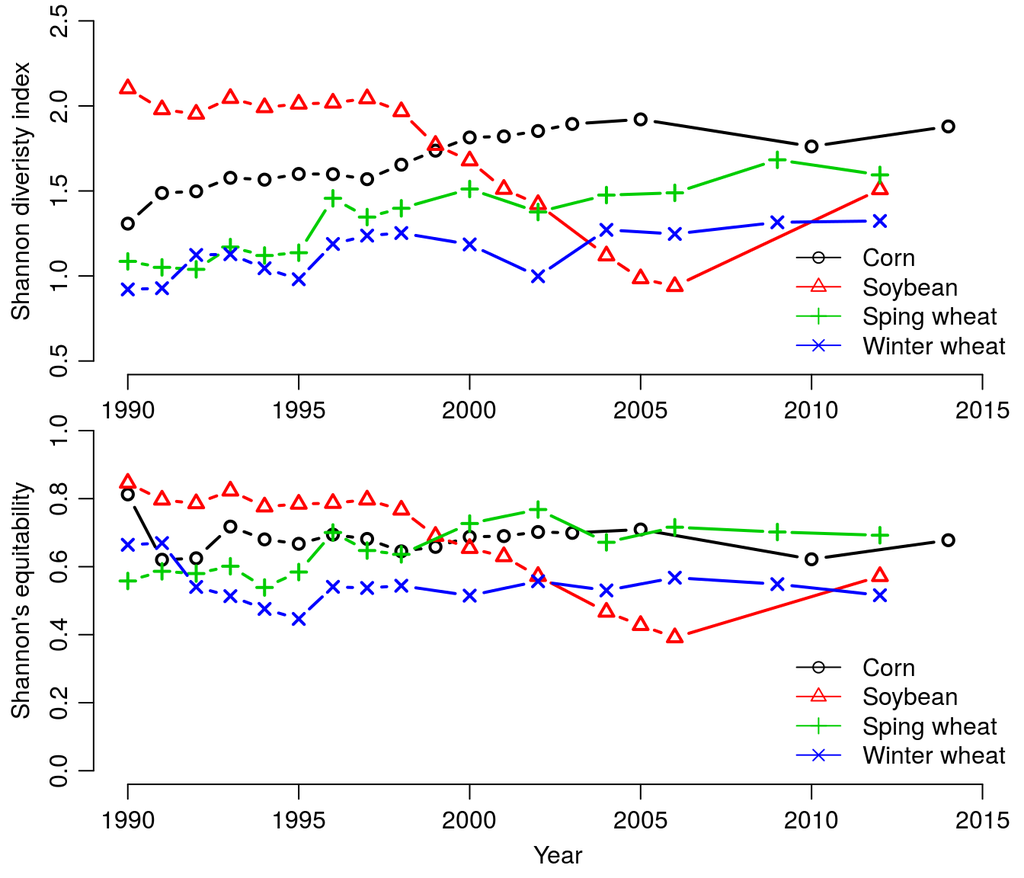

**Figure 1. Herbicide site of action diversity (top) and evenness (bottom) for four crops grown in the US, 1990 to 2014.**

**Table 5. Linear trend slopes (and P-values) for herbicide site of action diversity (H) and evenness (E) in four US crops.**

| crops | H_Slope | H_P.value | E_Slope | E_P.value |
| --- | --- | --- | --- | --- |
| Corn | 0.0219 | 0.0000 | -0.0012 | 0.5020 |
| Soybean | -0.0531 | 0.0001 | -0.0209 | 0.0000 |
| Spring wheat | 0.0282 | 0.0000 | 0.0077 | 0.0017 |
| Winter wheat | 0.0153 | 0.0015 | -0.0021 | 0.3867 |

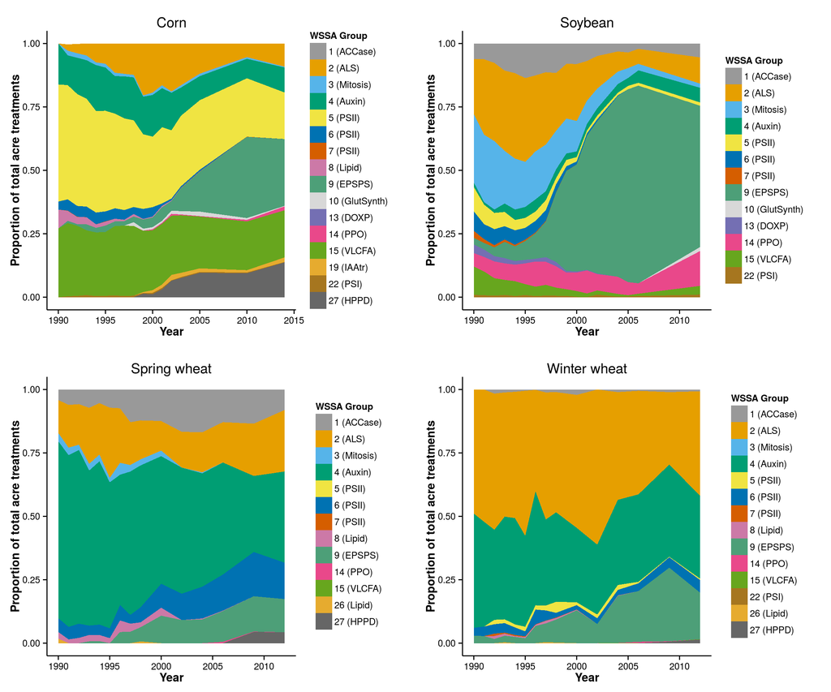

**Figure 2. Proportion of acre treatments by herbicide site of action for four crops in the US, 1990 to 2014. An acre treatment is a single application of a herbicide site of action applied to a single acre; for example a single mixture application of 2,4-D + dicamba + atrazine would equal three acre treatments (two group 4 plus one group 5).**

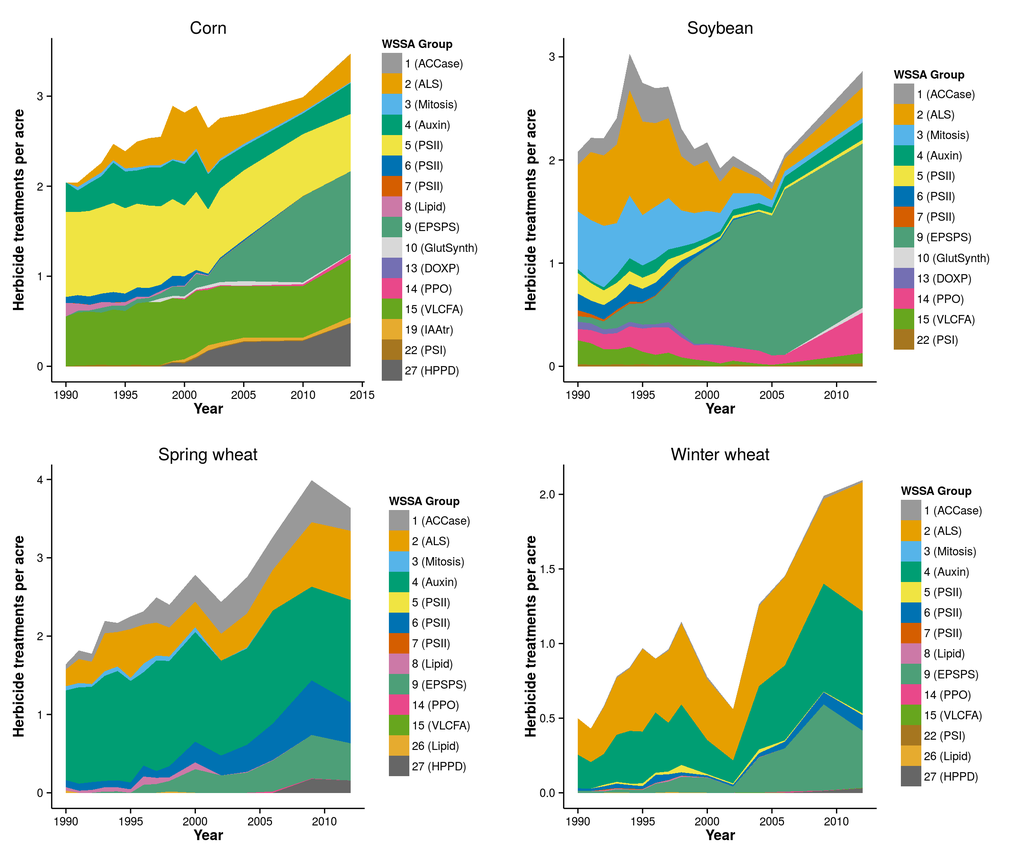

**Figure 3. Average herbicide acre treatments by site of action for four crops in the US, 1990 to 2014. An acre treatment is a single application of a herbicide site of action applied to a single acre; for example a single mixture application of 2,4-D + dicamba + atrazine would equal three acre treatments (two group 4 plus one group 5).**